# Convolutional Neural Networks

## Project: Write an Algorithm for a Dog Identification App

In this notebook, some template code has already been provided for you, and you will need to implement additional functionality to successfully complete this project. You will not need to modify the included code beyond what is requested. Sections that begin with **'(IMPLEMENTATION)'** in the header indicate that the following block of code will require additional functionality which you must provide. Instructions will be provided for each section, and the specifics of the implementation are marked in the code block with a 'TODO' statement. Please be sure to read the instructions carefully!

> **Note**: Once you have completed all of the code implementations, you need to finalize your work by exporting the Jupyter Notebook as an HTML document. Before exporting the notebook to html, all of the code cells need to have been run so that reviewers can see the final implementation and output. You can then export the notebook by using the menu above and navigating to **File -> Download as -> HTML (.html)**. Include the finished document along with this notebook as your submission.

In addition to implementing code, there will be questions that you must answer which relate to the project and your implementation. Each section where you will answer a question is preceded by a **'Question X'** header. Carefully read each question and provide thorough answers in the following text boxes that begin with **'Answer:'**. Your project submission will be evaluated based on your answers to each of the questions and the implementation you provide.

> **Note:** Code and Markdown cells can be executed using the **Shift + Enter** keyboard shortcut. Markdown cells can be edited by double-clicking the cell to enter edit mode.

The rubric contains *optional* "Stand Out Suggestions" for enhancing the project beyond the minimum requirements. If you decide to pursue the "Stand Out Suggestions", you should include the code in this Jupyter notebook.

### Why We're Here

In this notebook, you will make the first steps towards developing an algorithm that could be used as part of a mobile or web app. At the end of this project, your code will accept any user-supplied image as input. If a dog is detected in the image, it will provide an estimate of the dog's breed. If a human is detected, it will provide an estimate of the dog breed that is most resembling. The image below displays potential sample output of your finished project (... but we expect that each student's algorithm will behave differently!).

[figure not shown]

In this real-world setting, you will need to piece together a series of models to perform different tasks; for instance, the algorithm that detects humans in an image will be different from the CNN that infers dog breed. There are many points of possible failure, and no perfect algorithm exists. Your imperfect solution will nonetheless create a fun user experience!

### The Road Ahead

We break the notebook into separate steps. Feel free to use the links below to navigate the notebook.

- Step 0: Import Datasets
- Step 1: Detect Humans
- Step 2: Detect Dogs
- Step 3: Create a CNN to Classify Dog Breeds (from Scratch)
- Step 4: Create a CNN to Classify Dog Breeds (using Transfer Learning)
- Step 5: Write your Algorithm
- Step 6: Test Your Algorithm

## Step 0: Import Datasets

Make sure that you've downloaded the required human and dog datasets:

- Download the [dog dataset](https://s3-us-west-1.amazonaws.com/udacity-aind/dog-project/dogImages.zip). Unzip the folder and place it in this project's home directory, at the location `/dog_images`.
- Download the [human dataset](https://s3-us-west-1.amazonaws.com/udacity-aind/dog-project/lfw.zip). Unzip the folder and place it in the home directory, at location `/lfw`.

*Note: If you are using a Windows machine, you are encouraged to use [7zip](http://www.7-zip.org/) to extract the folder.*

In the code cell below, we save the file paths for both the human (LFW) dataset and dog dataset in the numpy arrays `human_files` and `dog_files`.

```python
import numpy as np
from glob import glob

# load filenames for human and dog images
human_files = np.array(glob("/data/lfw/*/*"))
dog_files = np.array(glob("/data/dog_images/*/*/*"))

# print number of images in each dataset
print('There are %d total human images.' % len(human_files))
print('There are %d total dog images.' % len(dog_files))
```

```
There are 13233 total human images.
There are 8351 total dog images.
```

## Step 1: Detect Humans

In this section, we use OpenCV's implementation of [Haar feature-based cascade classifiers](http://docs.opencv.org/trunk/d7/d8b/tutorial_py_face_detection.html) to detect human faces in images.

OpenCV provides many pre-trained face detectors, stored as XML files on [github](https://github.com/opencv/opencv/tree/master/data/haarcascades). We have downloaded one of these detectors and stored it in the `haarcascades` directory. In the next code cell, we demonstrate how to use this detector to find human faces in a sample image.

```
Number of faces detected: 1
```

```python
import cv2
import matplotlib.pyplot as plt
%matplotlib inline

# extract pre-trained face detector
face_cascade = cv2.CascadeClassifier('haarcascades/haarcascade_frontalface_alt.xml')

# load color (BGR) image
img = cv2.imread(human_files[0])
# convert BGR image to grayscale
gray = cv2.cvtColor(img, cv2.COLOR_BGR2GRAY)

# find faces in image
faces = face_cascade.detectMultiScale(gray)

# print number of faces detected in the image
print('Number of faces detected:', len(faces))

# get bounding box for each detected face
for (x,y,w,h) in faces:
    # add bounding box to color image
    cv2.rectangle(img,(x,y),(x+w,y+h),(255,0,0),2)

# convert BGR image to RGB for plotting
cv_rgb = cv2.cvtColor(img, cv2.COLOR_BGR2RGB)

# display the image, along with bounding box
plt.imshow(cv_rgb)
plt.show()
```

Before using any of the face detectors, it is standard procedure to convert the images to grayscale. The `detectMultiScale` function executes the classifier stored in `face_cascade` and takes the grayscale image as a parameter.

In the above code, `faces` is a numpy array of detected faces, where each row corresponds to a detected face. Each detected face is a 1D array with four entries that specifies the bounding box of the detected face. The first two entries in the array (extracted in the above code as `x` and `y`) specify the horizontal and vertical positions of the top left corner of the bounding box. The last two entries in the array (extracted here as `w` and `h`) specify the width and height of the box.

### Write a Human Face Detector

We can use this procedure to write a function that returns `True` if a human face is detected in an image and `False` otherwise. This function, aptly named `face_detector`, takes a string-valued file path to an image as input and appears in the code block below.

```python
# returns "True" if face is detected in image stored at img_path
def face_detector(img_path):
    img = cv2.imread(img_path)
    gray = cv2.cvtColor(img, cv2.COLOR_BGR2GRAY)
    faces = face_cascade.detectMultiScale(gray)
    return len(faces) > 0
```

### (IMPLEMENTATION) Assess the Human Face Detector

**Question 1:** Use the code cell below to test the performance of the `face_detector` function.

- What percentage of the first 100 images in `human_files` have a detected human face?
- What percentage of the first 100 images in `dog_files` have a detected human face?

Ideally, we would like 100% of human images with a detected face and 0% of dog images with a detected face. You will see that our algorithm falls short of this goal, but still gives acceptable performance. We extract the file paths for the first 100 images from each of the datasets and store them in the numpy arrays `human_files_short` and `dog_files_short`.

**Answer:** (You can print out your results and/or write your percentages in this cell)

Humane humans: 98%

Humane dogs: 17%

I believe this is due to the fact that our human detector is actually face detector which looks for features like eyes, nose, etc. It is possible therefore that it might detect a "face" in dog image and hence, thinks it is a human...!!!

```python
from tqdm import tqdm

human_files_short = human_files[:100]
dog_files_short = dog_files[:100]

#-#-# Do NOT modify the code above this line. #-#-#

## TODO: Test the performance of the face_detector algorithm
## on the images in human_files_short and dog_files_short.
humane_humans = 0
for f in human_files_short:
    if face_detector(f):
        humane_humans+=1

humane_dogs = 0
for f in dog_files_short:
    if face_detector(f):
        humane_dogs+=1
print("Humane humans: "+str(humane_humans)+"%")
print("Humane dogs: "+str(humane_dogs)+"%")
```

```
Humane humans: 98%
Humane dogs: 17%
```

We suggest the face detector from OpenCV as a potential way to detect human images in your algorithm, but you are free to explore other approaches, especially approaches that make use of deep learning :). Please use the code cell below to design and test your own face detection algorithm. If you decide to pursue this *optional* task, report performance on `human_files_short` and `dog_files_short`.

```python
### (Optional)
### TODO: Test performance of anotherface detection algorithm.
### Feel free to use as many code cells as needed.
```

## Step 2: Detect Dogs

In this section, we use a [pre-trained model](http://pytorch.org/docs/master/torchvision/models.html) to detect dogs in images.

### Obtain Pre-trained VGG-16 Model

The code cell below downloads the VGG-16 model, along with weights that have been trained on [ImageNet](http://www.image-net.org/), a very large, very popular dataset used for image classification and other vision tasks. ImageNet contains over 10 million URLs, each linking to an image containing an object from one of [1000 categories](https://gist.github.com/yrevar/942d3a0ac09ec9e5eb3a).

```python
import torch
import torchvision.models as models

# define VGG16 model
VGG16 = models.vgg16(pretrained=True)

# check if CUDA is available
use_cuda = torch.cuda.is_available()

# move model to GPU if CUDA is available
if use_cuda:
    VGG16 = VGG16.cuda()
```

```
Downloading: "https://download.pytorch.org/models/vgg16-397923af.pth" to /root/.torch/models/vgg16-397923af.pth
```

Given an image, this pre-trained VGG-16 model returns a prediction (derived from the 1000 possible categories in ImageNet) for the object that is contained in the image.

### (IMPLEMENTATION) Making Predictions with a Pre-trained Model

In the next code cell, you will write a function that accepts a path to an image (such as `'dogImages/train/001.Affenpinscher/Affenpinscher_00001.jpg'`) as input and returns the index corresponding to the ImageNet class that is predicted by the pre-trained VGG-16 model. The output should always be an integer between 0 and 999, inclusive.

Before writing the function, make sure that you take the time to learn how to appropriately pre-process tensors for pre-trained models in the [PyTorch documentation](http://pytorch.org/docs/stable/torchvision/models.html).

```python
from PIL import Image
import torchvision.transforms as transforms
import cv2

data_transform = transforms.Compose([transforms.CenterCrop(224),transforms.ToTensor()])

def VGG16_predict(img_path):
    '''
    Use pre-trained VGG-16 model to obtain index corresponding to
    predicted ImageNet class for image at specified path

    Args:
        img_path: path to an image

    Returns:
        Index corresponding to VGG-16 model's prediction
    '''

    ## TODO: Complete the function.
    ## Load and pre-process an image from the given img_path
    ## Return the *index* of the predicted class for that image
    VGG16.eval()
    img = (data_transform(Image.open(img_path)).float()).unsqueeze(0)
    if use_cuda:
        img = img.cuda()
    output = VGG16(img)
    _, preds_tensor = torch.max(output, 1)
    preds = np.squeeze(preds_tensor.numpy()) if not use_cuda else np.squeeze(preds_tensor.cpu().numpy())
    #print(preds)
    return preds # predicted class index

#print('Prediction')
#print(VGG16_predict(dog_files_short[0]))
#VGG16_predict(dog_files_short[0])
#VGG16_predict(dog_files_short[0])
```

### (IMPLEMENTATION) Write a Dog Detector

While looking at the [dictionary](https://gist.github.com/yrevar/942d3a0ac09ec9e5eb3a), you will notice that the categories corresponding to dogs appear in an uninterrupted sequence and correspond to dictionary keys 151-268, inclusive, to include all categories from `'Chihuahua'` to `'Mexican hairless'`. Thus, in order to check to see if an image is predicted to contain a dog by the pre-trained VGG-16 model, we need only check if the pre-trained model predicts an index between 151 and 268 (inclusive).

Use these ideas to complete the `dog_detector` function below, which returns `True` if a dog is detected in an image (and `False` if not).

```python
### returns "True" if a dog is detected in the image stored at img_path
def dog_detector(img_path):
    ## TODO: Complete the function.
    myclassind = VGG16_predict(img_path)

    return (myclassind<269 and myclassind>150) # true/false

#print(dog_detector(dog_files_short[10]))
```

### (IMPLEMENTATION) Assess the Dog Detector

**Question 2:** Use the code cell below to test the performance of your `dog_detector` function.

- What percentage of the images in `human_files_short` have a detected dog?
- What percentage of the images in `dog_files_short` have a detected dog?

**Answer:**

Dogly humans: 0%

Dogly dogs: 59%

Good to see that, dog detector does not detect any "dog" among humans...!!! :) At least in the small subset that we passed...!!!

```python
### TODO: Test the performance of the dog_detector function
### on the images in human_files_short and dog_files_short.

#-#-# Do NOT modify the code above this line. #-#-#

## TODO: Test the performance of the face_detector algorithm
## on the images in human_files_short and dog_files_short.
dogly_humans = 0
for f in human_files_short:
    if dog_detector(f):
        dogly_humans+=1

dogly_dogs = 0
for f in dog_files_short:
    if dog_detector(f):
        dogly_dogs+=1
print("Dogly humans: "+str(dogly_humans)+"%")
print("Dogly dogs: "+str(dogly_dogs)+"%")
```

```
Dogly humans: 0%
Dogly dogs: 59%
```

We suggest VGG-16 as a potential network to detect dog images in your algorithm, but you are free to explore other pre-trained networks (such as [Inception-v3](http://pytorch.org/docs/master/torchvision/models.html#inception-v3), [ResNet-50](http://pytorch.org/docs/master/torchvision/models.html#id3), etc). Please use the code cell below to test other pre-trained PyTorch models. If you decide to pursue this *optional* task, report performance on `human_files_short` and `dog_files_short`.

```python
### (Optional)
### TODO: Report the performance of another pre-trained network.
### Feel free to use as many code cells as needed.
```

## Step 3: Create a CNN to Classify Dog Breeds (from Scratch)

Now that we have functions for detecting humans and dogs in images, we need a way to predict breed from images. In this step, you will create a CNN that classifies dog breeds. You must create your CNN *from scratch* (so, you can't use transfer learning *yet*!), and you must attain a test accuracy of at least 10%. In Step 4 of this notebook, you will have the opportunity to use transfer learning to create a CNN that attains greatly improved accuracy.

We mention that the task of assigning breed to dogs from images is considered exceptionally challenging. To see why, consider that *even a human* would have trouble distinguishing between a Brittany and a Welsh Springer Spaniel.

| Brittany | Welsh Springer Spaniel |
| --- | --- |

It is not difficult to find other dog breed pairs with minimal inter-class variation (for instance, Curly-Coated Retrievers and American Water Spaniels).

| Curly-Coated Retriever | American Water Spaniel |
| --- | --- |

Likewise, recall that labradors come in yellow, chocolate, and black. Your vision-based algorithm will have to conquer this high intra-class variation to determine how to classify all of these different shades as the same breed.

| Yellow Labrador | Chocolate Labrador | Black Labrador |
| --- | --- | --- |

We also mention that random chance presents an exceptionally low bar: setting aside the fact that the classes are slightly imabalanced, a random guess will provide a correct answer roughly 1 in 133 times, which corresponds to an accuracy of less than 1%.

Remember that the practice is far ahead of the theory in deep learning. Experiment with many different architectures, and trust your intuition. And, of course, have fun!

### (IMPLEMENTATION) Specify Data Loaders for the Dog Dataset

Use the code cell below to write three separate [data loaders](http://pytorch.org/docs/stable/data.html#torch.utils.data.DataLoader) for the training, validation, and test datasets of dog images (located at `dog_images/train`, `dog_images/valid`, and `dog_images/test`, respectively). You may find [this documentation on custom datasets](http://pytorch.org/docs/stable/torchvision/datasets.html) to be a useful resource. If you are interested in augmenting your training and/or validation data, check out the wide variety of [transforms](http://pytorch.org/docs/stable/torchvision/transforms.html?highlight=transform)!

```python
import torch
import os
from torchvision import datasets
from PIL import ImageFile
ImageFile.LOAD_TRUNCATED_IMAGES = True

### TODO: Write data loaders for training, validation, and test sets
## Specify appropriate transforms, and batch_sizes

import torchvision.transforms as transforms
from torch.utils.data.sampler import SubsetRandomSampler

# number of subprocesses to use for data loading
num_workers = 0
# how many samples per batch to load
batch_size = 20
# percentage of training set to use as validation
valid_size = 0.2
#print(os.listdir('/data/dog_images/test'))
# convert data to a normalized torch.FloatTensor
transform = transforms.Compose([
    transforms.RandomAffine(degrees=180),
    transforms.CenterCrop(299),
    transforms.ToTensor()
    ])
transform2 = transforms.Compose([
    transforms.CenterCrop(299),
    transforms.ToTensor()
    ])

# choose the training and test datasets
train_data = datasets.ImageFolder(root='/data/dog_images/train',transform=transform)
valid_data = datasets.ImageFolder(root='/data/dog_images/valid',transform=transform)
test_data = datasets.ImageFolder(root='/data/dog_images/test',transform=transform2)

# prepare data loaders (combine dataset and sampler)
train_loader = torch.utils.data.DataLoader(train_data, batch_size=batch_size,
    shuffle=True, num_workers=num_workers)
print(train_loader)
valid_loader = torch.utils.data.DataLoader(valid_data, batch_size=batch_size,
    shuffle=True, num_workers=num_workers)
test_loader = torch.utils.data.DataLoader(test_data, batch_size=batch_size,
    num_workers=num_workers)

# specify the image classes
classes = os.listdir('/data/dog_images/train')
print(len(classes))
bid = 1
for a,b in train_loader:
    print("batch: "+ str(bid))
    print(a.shape)
    print(b.shape)
    bid+=1
    break
```

```
<torch.utils.data.dataloader.DataLoader object at 0x7f8a24b01f98>
133
batch: 1
torch.Size([20, 3, 299, 299])
torch.Size([20])
```

**Question 3:** Describe your chosen procedure for preprocessing the data.

- How does your code resize the images (by cropping, stretching, etc)? What size did you pick for the input tensor, and why?
- Did you decide to augment the dataset? If so, how (through translations, flips, rotations, etc)? If not, why not?

**Answer**:

1. In this part of project, I am using center crop with size 299 for all the images. The reason is the network I am designing is losely based on well known Inception v3 model which takes input images of size 299X299.
2. In addition to crop, during training I use random affine transforms with rotation from -180 degrees to 180 degrees. This is to make network rotation invariant.

### (IMPLEMENTATION) Model Architecture

Create a CNN to classify dog breed. Use the template in the code cell below.

```python
import torch
import torch.nn as nn
import torch.nn.functional as F
from torchvision.models.inception import InceptionA, BasicConv2d



# check if CUDA is available
use_cuda = torch.cuda.is_available()

print("Cuda "+str(use_cuda))



class InceptionAux(nn.Module):

    def __init__(self, in_channels, num_classes):
        super(InceptionAux, self).__init__()
        self.conv0 = BasicConv2d(in_channels, 128, kernel_size=1)
        self.conv1 = BasicConv2d(128, 768, kernel_size=11)
        self.conv1.stddev = 0.01
        self.fc = nn.Linear(768, num_classes)
        self.fc.stddev = 0.001

    def forward(self, x):
        # 17 x 17 x 768
        #Till A 35 x 35 x 288
        #print('Inside Aux')
        #print(x.shape)
        x = F.avg_pool2d(x, kernel_size=5, stride=3)

        # 5 x 5 x 768
        # 11 X 11 X 288
        #print(x.shape)
        x = self.conv0(x)
        #print(x.shape)
        # 5 x 5 x 128
        # 11 X 11 X 128
        x = self.conv1(x)
        #print(x.shape)
        # 1 x 1 x 768
        # 1 X 1 X 768
        x = x.view(x.size(0), -1)
        #print(x.shape)
        # 768
        x = self.fc(x)
        # 1000
        return x




# define the CNN architecture
class Net(nn.Module):
    ### TODO: choose an architecture, and complete the class
    def __init__(self, num_classes=1000, aux_logits=True, transform_input=False):
        super(Net, self).__init__()
        ## Define layers of a CNN

        self.aux_logits = aux_logits
        self.transform_input = transform_input
        self.Conv2d_1a_3x3 = BasicConv2d(3, 32, kernel_size=3, stride=2)
        self.Conv2d_2a_3x3 = BasicConv2d(32, 32, kernel_size=3)
        self.Conv2d_2b_3x3 = BasicConv2d(32, 64, kernel_size=3, padding=1)
        self.Conv2d_3b_1x1 = BasicConv2d(64, 80, kernel_size=1)
        self.Conv2d_4a_3x3 = BasicConv2d(80, 192, kernel_size=3)
        self.Mixed_5b = InceptionA(192, pool_features=32)
        self.Mixed_5c = InceptionA(256, pool_features=64)
        self.Mixed_5d = InceptionA(288, pool_features=64)
        #self.Mixed_6a = InceptionB(288)
        #self.Mixed_6b = InceptionC(768, channels_7x7=128)
        #self.Mixed_6c = InceptionC(768, channels_7x7=160)
        #self.Mixed_6d = InceptionC(768, channels_7x7=160)
        #self.Mixed_6e = InceptionC(768, channels_7x7=192)
        if aux_logits:
            #self.AuxLogits = InceptionAux(768, num_classes)
            self.AuxLogits = InceptionAux(288, num_classes)

        #self.Mixed_7a = InceptionD(768)
        #self.Mixed_7b = InceptionE(1280)
        #self.Mixed_7c = InceptionE(2048)

        self.fcA = nn.Linear(288,num_classes)
        self.fc = nn.Linear(2048, num_classes)

        for m in self.modules():
            if isinstance(m, nn.Conv2d) or isinstance(m, nn.Linear):
                import scipy.stats as stats
                stddev = m.stddev if hasattr(m, 'stddev') else 0.1
                X = stats.truncnorm(-2, 2, scale=stddev)
                values = torch.Tensor(X.rvs(m.weight.data.numel()))
                values = values.view(m.weight.data.size())
                m.weight.data.copy_(values)
            elif isinstance(m, nn.BatchNorm2d):
                m.weight.data.fill_(1)
                m.bias.data.zero_()








    def forward(self, x):
        ## Define forward behavior
        if self.transform_input:
            x = x.clone()
            x[:, 0] = x[:, 0] * (0.229 / 0.5) + (0.485 - 0.5) / 0.5
            x[:, 1] = x[:, 1] * (0.224 / 0.5) + (0.456 - 0.5) / 0.5
            x[:, 2] = x[:, 2] * (0.225 / 0.5) + (0.406 - 0.5) / 0.5
        # 299 x 299 x 3
        #print(x.shape)
        x = self.Conv2d_1a_3x3(x)
        #print(x.shape)
        # 149 x 149 x 32
        x = self.Conv2d_2a_3x3(x)
        #print(x.shape)
        # 147 x 147 x 32
        x = self.Conv2d_2b_3x3(x)
        #print(x.shape)

        # 147 x 147 x 64
        x = F.max_pool2d(x, kernel_size=3, stride=2)
        #print(x.shape)


        # 73 x 73 x 64
        x = self.Conv2d_3b_1x1(x)
       # print(x.shape)

        # 73 x 73 x 80
        x = self.Conv2d_4a_3x3(x)
        #print(x.shape)

        # 71 x 71 x 192
        x = F.max_pool2d(x, kernel_size=3, stride=2)
        #print(x.shape)

        # 35 x 35 x 192
        x = self.Mixed_5b(x)
        #print(x.shape)

        # 35 x 35 x 256
        x = self.Mixed_5c(x)
        #print(x.shape)


        # 35 x 35 x 288
        x = self.Mixed_5d(x)
        #print(x.shape)

        # 35 x 35 x 288
        #x = self.Mixed_6a(x)
        # 17 x 17 x 768
        #x = self.Mixed_6b(x)
        # 17 x 17 x 768
        #x = self.Mixed_6c(x)
        # 17 x 17 x 768
        #x = self.Mixed_6d(x)
        # 17 x 17 x 768
        #x = self.Mixed_6e(x)
        # 17 x 17 x 768
        #Till A 35 x 35 x 288
        if self.training and self.aux_logits:
            aux = self.AuxLogits(x)

        # 17 x 17 x 768
        #x = self.Mixed_7a(x)
        # 8 x 8 x 1280
        #x = self.Mixed_7b(x)
        # 8 x 8 x 2048
        #x = self.Mixed_7c(x)

        # 8 x 8 x 2048
        #Till A 35 x 35 x 288
        x = F.avg_pool2d(x, kernel_size=35)
        #print(x.shape)

        #x = F.avg_pool2d(x, kernel_size=8)

        # 1 x 1 x 2048
        #Till A 1 x 1 x 288
        x = F.dropout(x, training=self.training)
        #print(x.shape)

        # 1 x 1 x 2048
        #Till A 1 x 1 x 288
        x = x.view(x.size(0), -1)
        #print(x.shape)

        # 2048
        #x = self.fc(x)
        #Till A 288
        x = self.fcA(x)
        #print(x.shape)

        #x = F.relu(x)
        x = F.log_softmax(x,dim=1)
        #print(x.shape)

        # 1000 (num_classes)
        if self.training and self.aux_logits:
            return x, aux
        return x
#-#-# You so NOT have to modify the code below this line. #-#-#

mytraining = True
myaux_logits = False
num_classes = len(classes)
# instantiate the CNN
model_scratch = Net(num_classes=num_classes, aux_logits=myaux_logits, transform_input=False)

# move tensors to GPU if CUDA is available
if use_cuda:
    model_scratch.cuda()
```

```
Cuda True
```

**Question 4:** Outline the steps you took to get to your final CNN architecture and your reasoning at each step.

**Answer:**

I read a couple of good models for images. I came across a model called Inception and thought the idea is very good. From what I understan, usual deep learning models go deeper and deeper for more accuracy. However, the inception model also goes "wider".

When we train a convolutional neural network, we usually have layers of convolutional kernels stacked one after another. However, inception architecture suggests that, we could have multiple convolutional kernels with different sizes even at the same level.

I thought this kind of architecture is very well suited for dog breed classification due to following reasons:

1. As suggested in the notebook, the dog breed classification is a problem of fine level classification, where, the inter class similarity is very high. That means, the difference between a cat and a dog is very large, compared to difference between two dogs though different breeds.
2. Now, imagin what a deeper level CNN does. It tries to learn patterns within patterns within patterns and so on. The more levels we have, the higher level of features it extracts.
3. But, when it comes to finer level classification, higher level features may not help, because, they would be very similar. Hence, we need to focus more on lower level features. Hence, we need to find more number of patterns from the input itself and this is where, "wider" architectures like inception would help.
4. By having different size kernels at input itself, would give us more number of patterns.
5. Hence, I decided to base my architecture on inception model.

In fact, I took the architecture of inception model via its source. I took only first cut of the inception model and used that as a model from scratch. Note that I did not use the pretrained model here. I just modelled my architecture similar to first part of inception model and retrained that part from scratch. I used fully-connected layer at the end of it.

[figure not shown]

As seen above, I used the part till the first auxillary output for the model from scratch. Please note that, I didn't download inception model here, I just took its source code and took a part of its layers as my model and trained from scratch. (I don't have expertise on "wider" model architecture but I tried to understand it and tweak it.)

A good discussion on inception model can be found here: https://towardsdatascience.com/a-simple-guide-to-the-versions-of-the-inception-network-7fc52b863202 Source of inception model: https://github.com/pytorch/vision/blob/master/torchvision/models/inception.py

Final Model has below layers:

self.Conv2d_1a_3x3 = BasicConv2d(3, 32, kernel_size=3, stride=2)

```
    self.Conv2d_2a_3x3 = BasicConv2d(32, 32, kernel_size=3)

    self.Conv2d_2b_3x3 = BasicConv2d(32, 64, kernel_size=3, padding=1)

    self.Conv2d_3b_1x1 = BasicConv2d(64, 80, kernel_size=1)

    self.Conv2d_4a_3x3 = BasicConv2d(80, 192, kernel_size=3)

    self.Mixed_5b = InceptionA(192, pool_features=32)

    self.Mixed_5c = InceptionA(256, pool_features=64)

    self.Mixed_5d = InceptionA(288, pool_features=64)

    self.fcA = nn.Linear(288,num_classes) ### Added by me
```

Note that I had to take care of the input sizes in several places and this model is very different from inception model

### (IMPLEMENTATION) Specify Loss Function and Optimizer

Use the next code cell to specify a [loss function](http://pytorch.org/docs/stable/nn.html#loss-functions) and [optimizer](http://pytorch.org/docs/stable/optim.html). Save the chosen loss function as `criterion_scratch`, and the optimizer as `optimizer_scratch` below.

```python
import torch.nn as nn
import torch.optim as optim
import numpy as np
### TODO: select loss function
#criterion_scratch = nn.CrossEntropyLoss()
criterion_scratch = nn.NLLLoss()

# specify optimizer
optimizer_scratch = optim.Adam(model_scratch.parameters(), lr=0.001)
```

### (IMPLEMENTATION) Train and Validate the Model

Train and validate your model in the code cell below. [Save the final model parameters](http://pytorch.org/docs/master/notes/serialization.html) at filepath `'model_scratch.pt'`.

```python
#train_loss_seq = []
#valid_loss_seq = []

def train(n_epochs, train_loader,valid_loader, model, optimizer, criterion, use_cuda, save_path, testcode = False):
    """returns trained model"""
    # initialize tracker for minimum validation loss
    valid_loss_min = np.Inf

    for epoch in range(1, n_epochs+1):
        # initialize variables to monitor training and validation loss
        train_loss = 0.0
        valid_loss = 0.0
        bid = 0
        ###################
        # train the model #
        ###################
        model.train()
        for (data, target) in train_loader:
            # move to GPU
            bid +=1
            if(bid%100==0):
                print('Batch '+str(bid))
            if use_cuda:
                data, target = data.cuda(), target.cuda()
            ## find the loss and update the model parameters accordingly
            ## record the average training loss, using something like
            ## train_loss = train_loss + ((1 / (batch_idx + 1)) * (loss.data - train_loss))
            # clear the gradients of all optimized variables
            optimizer.zero_grad()
            # forward pass: compute predicted outputs by passing inputs to the model
            output = None
            if myaux_logits:
                output, auxOutput = model(data)
            else:
                output = model(data)
            #print(output)
            #print(target)

            #print('Target: '+str(target.shape))
            #print('Output: '+str(output.shape))
            # calculate the batch loss
            loss = criterion(output, target)
            # backward pass: compute gradient of the loss with respect to model parameters
            loss.backward()
            # perform a single optimization step (parameter update)
            optimizer.step()
            # update training loss
            train_loss += loss.item()*data.size(0)
            if testcode:
                break




        ######################
        # validate the model #
        ######################
        model.eval()
        bid = 0
        for (data, target) in valid_loader:
            # move to GPU
            bid+=1
            if(bid%100==0):
                print('Valid batch '+str(bid))
            if use_cuda:
                data, target = data.cuda(), target.cuda()
            ## update the average validation loss
            # forward pass: compute predicted outputs by passing inputs to the model
            output = model(data)
            # calculate the batch loss
            loss = criterion(output, target)
            # update average validation loss
            valid_loss += loss.item()*data.size(0)
            if testcode:
                break

        # calculate average losses
        train_loss = train_loss/len(train_loader.dataset)
        valid_loss = valid_loss/len(valid_loader.dataset)
        train_loss_seq.append(train_loss)
        valid_loss_seq.append(valid_loss)


        # print training/validation statistics
        print('Epoch: {} \tTraining Loss: {:.6f} \tValidation Loss: {:.6f}'.format(
            epoch,
            train_loss,
            valid_loss
            ))

        ## TODO: save the model if validation loss has decreased
        # save model if validation loss has decreased
        if valid_loss <= valid_loss_min:
            print('Validation loss decreased ({:.6f} --> {:.6f}).  Saving model ...'.format(valid_loss_min,valid_loss))
            torch.save(model.state_dict(), 'model_scratch.pt')
            valid_loss_min = valid_loss
    # return trained model
    return model


model_scratch.load_state_dict(torch.load('model_scratch.pt'))
# train the model
model_scratch = train(4, train_loader,valid_loader, model_scratch, optimizer_scratch, criterion_scratch, use_cuda, 'model_scratch.pt', testcode = False)

# load the model that got the best validation accuracy
model_scratch.load_state_dict(torch.load('model_scratch.pt'))
```

```
Batch 100
Batch 200
Batch 300
Epoch: 1 	Training Loss: 4.099852 	Validation Loss: 4.083051
Validation loss decreased (inf --> 4.083051).  Saving model ...
Batch 100
Batch 200
Batch 300
Epoch: 2 	Training Loss: 4.016039 	Validation Loss: 3.973187
Validation loss decreased (4.083051 --> 3.973187).  Saving model ...
Batch 100
Batch 200
Batch 300
Epoch: 3 	Training Loss: 3.916057 	Validation Loss: 3.970483
Validation loss decreased (3.973187 --> 3.970483).  Saving model ...
Batch 100
Batch 200
Batch 300
Epoch: 4 	Training Loss: 3.853336 	Validation Loss: 3.809487
Validation loss decreased (3.970483 --> 3.809487).  Saving model ...
```

I trained this network around 2 times (note I load previous state every time.) In total I trained it for around 9 epochs.

### (IMPLEMENTATION) Test the Model

Try out your model on the test dataset of dog images. Use the code cell below to calculate and print the test loss and accuracy. Ensure that your test accuracy is greater than 10%.

```python
import pickle
model_scratch = Net(num_classes=num_classes, aux_logits=myaux_logits, transform_input=False)
model_scratch.load_state_dict(torch.load('model_scratch.pt'))
# move tensors to GPU if CUDA is available
if use_cuda:
    model_scratch.cuda()




all_pred = []
all_targets = []

pickle.dump(all_pred,open('all_pred.pkl','wb'))
pickle.dump(all_targets,open('all_targets.pkl','wb'))

def test(loaders, model, criterion, use_cuda, testcode = False):

    # monitor test loss and accuracy
    test_loss = 0.
    correct = 0.
    total = 0.

    model.eval()
    for (data, target) in test_loader:
        # move to GPU
        if use_cuda:
            data, target = data.cuda(), target.cuda()
        # forward pass: compute predicted outputs by passing inputs to the model
        output = model(data)
        # calculate the loss
        loss = criterion(output, target)
        # update average test loss
        test_loss += loss.item()*data.size(0)

        #test_loss = test_loss + ((1 / (batch_idx + 1)) * (loss.data - test_loss))
        # convert output probabilities to predicted class
        pred = output.data.max(1, keepdim=True)[1]

        #print(pred)
        all_pred.extend(pred.tolist())
        all_targets.extend(target.tolist())
        #print(target)
        # compare predictions to true label
        correct += np.sum(np.squeeze(pred.eq(target.data.view_as(pred))).cpu().numpy())
        total += data.size(0)
        if testcode:
            break

    test_loss = test_loss/len(test_loader.dataset)

    print('Test Loss: {:.6f}\n'.format(test_loss))
    pickle.dump(test_loss,open('test_loss.pkl','wb'))

    print('\nTest Accuracy: %2d%% (%2d/%2d)' % (
        100. * correct / total, correct, total))

# call test function
test(None, model_scratch, criterion_scratch, use_cuda,testcode = False)

pickle.dump(all_pred,open('all_pred.pkl','wb'))
pickle.dump(all_targets,open('all_targets.pkl','wb'))
```

```
Test Loss: 3.800003


Test Accuracy: 11% (99/836)
```

### Result

As seen above, even with a small network like this, I was able to surpass the target accuracy of 10%. I could get 11% accuracy. With more epochs we could get better accuracy, but I am stopping the training in order to save GPU cycles.

## Step 4: Create a CNN to Classify Dog Breeds (using Transfer Learning)

You will now use transfer learning to create a CNN that can identify dog breed from images. Your CNN must attain at least 60% accuracy on the test set.

### (IMPLEMENTATION) Specify Data Loaders for the Dog Dataset

Use the code cell below to write three separate [data loaders](http://pytorch.org/docs/master/data.html#torch.utils.data.DataLoader) for the training, validation, and test datasets of dog images (located at `dogImages/train`, `dogImages/valid`, and `dogImages/test`, respectively).

If you like, **you are welcome to use the same data loaders from the previous step**, when you created a CNN from scratch.

```python
import torch
import os
from torchvision import datasets
from PIL import ImageFile
ImageFile.LOAD_TRUNCATED_IMAGES = True

### TODO: Write data loaders for training, validation, and test sets
## Specify appropriate transforms, and batch_sizes

import torchvision.transforms as transforms
from torch.utils.data.sampler import SubsetRandomSampler

# number of subprocesses to use for data loading
num_workers = 0
# how many samples per batch to load
batch_size = 20
# percentage of training set to use as validation
valid_size = 0.2
#print(os.listdir('/data/dog_images/test'))
# convert data to a normalized torch.FloatTensor
transform = transforms.Compose([
    transforms.RandomAffine(degrees=180),
    transforms.CenterCrop(299),
    transforms.ToTensor()
    ])
transform2 = transforms.Compose([
    transforms.CenterCrop(299),
    transforms.ToTensor()
    ])

# choose the training and test datasets
train_data = datasets.ImageFolder(root='/data/dog_images/train',transform=transform)
valid_data = datasets.ImageFolder(root='/data/dog_images/valid',transform=transform)
test_data = datasets.ImageFolder(root='/data/dog_images/test',transform=transform2)

print(train_data.classes[0])
# prepare data loaders (combine dataset and sampler)
train_loader = torch.utils.data.DataLoader(train_data, batch_size=batch_size,
    shuffle=True, num_workers=num_workers)
print(train_loader)
valid_loader = torch.utils.data.DataLoader(valid_data, batch_size=batch_size,
    shuffle=True, num_workers=num_workers)
test_loader = torch.utils.data.DataLoader(test_data, batch_size=batch_size,
    num_workers=num_workers)

# specify the image classes
classes = os.listdir('/data/dog_images/train')
print(len(classes))
bid = 1
for a,b in train_loader:
    print("batch: "+ str(bid))
    print(a.shape)
    print(b.shape)
    bid+=1
    break
```

```
001.Affenpinscher
<torch.utils.data.dataloader.DataLoader object at 0x7ffb1b66f320>
133
batch: 1
torch.Size([20, 3, 299, 299])
torch.Size([20])
```

```
133
```

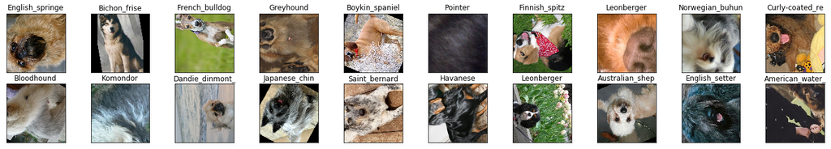

```python
## TODO: Specify data loaders
import os
import numpy as np
import torch

import torchvision
from torchvision import datasets, models, transforms
import matplotlib.pyplot as plt

%matplotlib inline
# Visualize some sample data

# obtain one batch of training images
dataiter = iter(train_loader)
images, labels = dataiter.next()
images = images.numpy() # convert images to numpy for display
classes = os.listdir('/data/dog_images/train')
classes = list(map(lambda x: x.split('.')[1], classes))
print(len(classes))
# plot the images in the batch, along with the corresponding labels
fig = plt.figure(figsize=(25, 4))
for idx in np.arange(20):
    ax = fig.add_subplot(2, 20/2, idx+1, xticks=[], yticks=[])
    plt.imshow(np.transpose(images[idx], (1, 2, 0)))
    mytitle = classes[labels[idx]]
    if len(mytitle)>15:
        mytitle = mytitle[:15]
    ax.set_title(mytitle)
```

### (IMPLEMENTATION) Model Architecture

Use transfer learning to create a CNN to classify dog breed. Use the code cell below, and save your initialized model as the variable `model_transfer`.

**Answer**

For transfer learning, I have decided to go for Inception v3 model. As I already explored a part of its architecture from scratch above, the plan is to see if the pretrained model of inception helps to improve the performance.

```python
import torchvision.models as models
import torch.nn as nn

## TODO: Specify model architecture
model_transfer = models.inception_v3(pretrained=True)
use_cuda = torch.cuda.is_available()
print(use_cuda)
```

```
Downloading: "https://download.pytorch.org/models/inception_v3_google-1a9a5a14.pth" to /root/.torch/models/inception_v3_google-1a9a5a14.pth
```

```
True
```

**Question 5:** Outline the steps you took to get to your final CNN architecture and your reasoning at each step. Describe why you think the architecture is suitable for the current problem.

After experimenting with a "wider" kind of network, the natural choice for the transfer learning was to utilize pretrained Inception model. The bemefits of wider network are already mentioned above.

1. As suggested in the notebook, the dog breed classification is a problem of fine level classification, where, the inter class similarity is very high. That means, the difference between a cat and a dog is very large, compared to difference between two dogs though different breeds.
2. Now, imagin what a deeper level CNN does. It tries to learn patterns within patterns within patterns and so on. The more levels we have, the higher level of features it extracts.
3. But, when it comes to finer level classification, higher level features may not help, because, they would be very similar. Hence, we need to focus more on lower level features. Hence, we need to find more number of patterns from the input itself and this is where, "wider" architectures like inception would help.
4. By having different size kernels at input itself, would give us more number of patterns.

[figure not shown]

Hence, I decided to use the inception model for transfer learning.

```python
print(model_transfer)
```

[output not shown]

[output cut: 357 more lines]

[output not shown]

```python
print(model_transfer.fc)
```

```
Linear(in_features=2048, out_features=1000, bias=True)
```

### Replace last linear layer

```python
# Freeze training for all layers


for param in model_transfer.parameters():
    param.requires_grad = False

num_classes = len(os.listdir('/data/dog_images/train'))
model_transfer.fc = nn.Linear(2048, num_classes, bias = True)
```

**Answer:**

1. I noticed that, inception v3 is trained on the ImageNet Dataset with millions of images and 1000 classes.
2. Dog breed classification that I am handling here, consists of leass than 10k images and 133 classes.
3. This is clearly **Small Dataset and Different Dataset** scenario.
4. Hence, I am going to use mostly pretrained Inception v3 model. But I will retrain the fully connected part of the model.

```python
if use_cuda:
    model_transfer = model_transfer.cuda()
```

### (IMPLEMENTATION) Specify Loss Function and Optimizer

Use the next code cell to specify a [loss function](http://pytorch.org/docs/master/nn.html#loss-functions) and [optimizer](http://pytorch.org/docs/master/optim.html). Save the chosen loss function as `criterion_transfer`, and the optimizer as `optimizer_transfer` below.

```python
import torch.optim as optim
import numpy as np

criterion_transfer = nn.CrossEntropyLoss()
optimizer_transfer = optim.Adam(model_transfer.fc.parameters(),lr = 0.001)
```

### (IMPLEMENTATION) Train and Validate the Model

Train and validate your model in the code cell below. [Save the final model parameters](http://pytorch.org/docs/master/notes/serialization.html) at filepath `'model_transfer.pt'`.

```python
# train the model
import pickle
#all_train_loss = []
#all_valid_loss = []
#pickle.dump(all_train_loss,open('all_train_transfer.pkl','wb'))
#pickle.dump(all_valid_loss,open('all_valid_transfer.pkl','wb'))

myaux_logits = True
all_train_loss = pickle.load(open('all_train_transfer.pkl','rb'))
all_valid_loss = pickle.load(open('all_train_transfer.pkl','rb'))

def train(n_epochs, train_loader,valid_loader, model, optimizer, criterion, use_cuda, save_path, testcode = False):
    """returns trained model"""
    # initialize tracker for minimum validation loss
    valid_loss_min = np.Inf

    for epoch in range(1, n_epochs+1):
        # initialize variables to monitor training and validation loss
        train_loss = 0.0
        valid_loss = 0.0
        bid = 0
        ###################
        # train the model #
        ###################
        model.train()
        for (data, target) in train_loader:
            # move to GPU
            bid +=1
            if(bid%100==0):
                print('Batch '+str(bid))
            if use_cuda:
                data, target = data.cuda(), target.cuda()
            ## find the loss and update the model parameters accordingly
            ## record the average training loss, using something like
            ## train_loss = train_loss + ((1 / (batch_idx + 1)) * (loss.data - train_loss))
            # clear the gradients of all optimized variables
            optimizer.zero_grad()
            # forward pass: compute predicted outputs by passing inputs to the model
            output = None
            if myaux_logits:
                mytuple = model(data)
                output = mytuple[0]
            else:
                output = model(data)
            #print(output)
            #print(target)

            #print('Target: '+str(target.shape))
            #print('Output: '+str(output.shape))
            # calculate the batch loss
            loss = criterion(output, target)
            # backward pass: compute gradient of the loss with respect to model parameters
            loss.backward()
            # perform a single optimization step (parameter update)
            optimizer.step()
            # update training loss
            train_loss += loss.item()*data.size(0)
            if testcode:
                break




        ######################
        # validate the model #
        ######################
        model.eval()
        with torch.no_grad():

            bid = 0
            for (data, target) in valid_loader:
                # move to GPU
                bid+=1
                if(bid%100==0):
                    print('Valid batch '+str(bid))
                if use_cuda:
                    data, target = data.cuda(), target.cuda()
                ## update the average validation loss
                # forward pass: compute predicted outputs by passing inputs to the model
                output = model(data)
                # calculate the batch loss
                loss = criterion(output, target)
                # update average validation loss
                valid_loss += loss.item()*data.size(0)
                if testcode:
                    break

        # calculate average losses
        train_loss = train_loss/len(train_loader.dataset)
        valid_loss = valid_loss/len(valid_loader.dataset)

        all_train_loss.append(train_loss)
        all_valid_loss.append(valid_loss)


        # print training/validation statistics
        print('Epoch: {} \tTraining Loss: {:.6f} \tValidation Loss: {:.6f}'.format(
            epoch,
            train_loss,
            valid_loss
            ))

        ## TODO: save the model if validation loss has decreased
        # save model if validation loss has decreased
        if valid_loss <= valid_loss_min:
            print('Validation loss decreased ({:.6f} --> {:.6f}).  Saving model ...'.format(valid_loss_min,valid_loss))
            torch.save(model.state_dict(), save_path)
            valid_loss_min = valid_loss
    # return trained model
    return model


#model_scratch.load_state_dict(torch.load('model_scratch.pt'))
# train the model
model_transfer_trained = model_transfer
model_transfer_trained.load_state_dict(torch.load('model_transfer.pt'))

model_transfer_trained = train(3, train_loader,valid_loader, model_transfer_trained, optimizer_transfer, criterion_transfer, use_cuda, 'model_transfer.pt', testcode = False)

# load the model that got the best validation accuracy (uncomment the line below)
model_transfer_trained.load_state_dict(torch.load('model_transfer.pt'))

pickle.dump(all_train_loss,open('all_train_transfer.pkl','wb'))
pickle.dump(all_valid_loss,open('all_valid_transfer.pkl','wb'))
```

```
Batch 100
Batch 200
Batch 300
Epoch: 1 	Training Loss: 2.661996 	Validation Loss: 2.148685
Validation loss decreased (inf --> 2.148685).  Saving model ...
Batch 100
Batch 200
Batch 300
Epoch: 2 	Training Loss: 2.235626 	Validation Loss: 1.865403
Validation loss decreased (2.148685 --> 1.865403).  Saving model ...
Batch 100
Batch 200
Batch 300
Epoch: 3 	Training Loss: 2.096088 	Validation Loss: 1.771404
Validation loss decreased (1.865403 --> 1.771404).  Saving model ...
```

### Result of training:

I trained the model for around 4 epochs. Following plot shows how quickly the loss decreases for the train and validation sets. One thing to note here is that validation loss is smaller than training loss. Though I am not sure about this surprising behavior one reason could be that images in validation data are actually simpler to classify. I stopped the training procedure earlier to save the GPU hours.

```
[3.912540305160477, 2.661995546903439, 2.235626133259185, 2.0960883301889113]
```

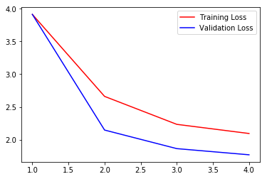

```python
import pickle
import matplotlib.pyplot as plt
%matplotlib inline

all_train_loss = pickle.load(open('all_train_transfer.pkl','rb'))
all_valid_loss = pickle.load(open('all_valid_transfer.pkl','rb'))
print(all_train_loss)
x = range(1,len(all_train_loss)+1)
plt.figure()
#plt.plot(x, x, 'r') # plotting t, a separately
plt.plot(x, all_train_loss, 'r', label='Training Loss') # plotting t, a separately
plt.legend()
plt.plot(x, all_valid_loss, 'b', label='Validation Loss') # plotting t, b separately
plt.legend()
```

### (IMPLEMENTATION) Test the Model

Try out your model on the test dataset of dog images. Use the code cell below to calculate and print the test loss and accuracy. Ensure that your test accuracy is greater than 60%.

```python
import pickle
#model_scratch = Net(num_classes=num_classes, aux_logits=myaux_logits, transform_input=False)
#model_scratch.load_state_dict(torch.load('model_scratch.pt'))
# move tensors to GPU if CUDA is available
if use_cuda:
    model_transfer_trained.cuda()




all_pred = []
all_targets = []

pickle.dump(all_pred,open('all_pred.pkl','wb'))
pickle.dump(all_targets,open('all_targets.pkl','wb'))

def test(loaders, model, criterion, use_cuda, testcode = False):

    # monitor test loss and accuracy
    test_loss = 0.
    correct = 0.
    total = 0.

    model.eval()
    for (data, target) in test_loader:
        # move to GPU
        if use_cuda:
            data, target = data.cuda(), target.cuda()
        # forward pass: compute predicted outputs by passing inputs to the model
        output = model(data)
        # calculate the loss
        loss = criterion(output, target)
        # update average test loss
        test_loss += loss.item()*data.size(0)

        #test_loss = test_loss + ((1 / (batch_idx + 1)) * (loss.data - test_loss))
        # convert output probabilities to predicted class
        pred = output.data.max(1, keepdim=True)[1]

        #print(pred)
        all_pred.extend(pred.tolist())
        all_targets.extend(target.tolist())
        #print(target)
        # compare predictions to true label
        correct += np.sum(np.squeeze(pred.eq(target.data.view_as(pred))).cpu().numpy())
        total += data.size(0)
        if testcode:
            break

    test_loss = test_loss/len(test_loader.dataset)

    print('Test Loss: {:.6f}\n'.format(test_loss))
    pickle.dump(test_loss,open('test_loss.pkl','wb'))

    print('\nTest Accuracy: %2d%% (%2d/%2d)' % (
        100. * correct / total, correct, total))

# call test function
with torch.no_grad():
    test(None, model_transfer_trained, criterion_transfer, use_cuda,testcode = False)

pickle.dump(all_pred,open('all_pred.pkl','wb'))
pickle.dump(all_targets,open('all_targets.pkl','wb'))
```

```
Test Loss: 0.891562


Test Accuracy: 76% (642/836)
```

### Results on Testing Data:

As can be seen above, we get a very good accuracy of 76% with only 4 epochs of training. It easily surpasses the threshold of 60% specified for the notebook.

I stopped the training to save GPU.

But we can have a look at few more insights about the test results as follows.

**Disclaimer**: The idea and plotting code for the below analysis was taken from below link and I don't claim the same. I just liked the way to analyze results this way because it gives more insights into why this problem is difficult.

```
https://towardsdatascience.com/dog-breed-classification-hands-on-approach-b5e4f88c333e
```

### Confusion Matrix:

Confusion matrix is a good way to display the classification (and more correctly misclassification) for each pair of classes. In a way, it shows which classes are more confusing for our classifier.

Below I plot the confusion matrix for our test data.

```python
import os
classes = test_data.classes
#classes = os.listdir('/data/dog_images/test')
#classes = list(map(lambda x: x.split('.')[1], classes))
import pickle
all_pred = pickle.load(open('all_pred.pkl','rb'))
all_targets = pickle.load(open('all_targets.pkl','rb'))
```

```python
all_pred2 = list(map(lambda x: x[0], all_pred))
print(len(all_pred2))
print(len(all_targets))
actual = list(map(lambda x: classes[x], all_pred2))
predicted = list(map(lambda x: classes[x], all_targets))
```

```
836
836
```

```python
import numpy as np
import pandas as pd
import matplotlib.pyplot as plt
from sklearn.metrics import confusion_matrix
import seaborn as sns
from pylab import rcParams
rcParams['figure.figsize'] = 10, 10
plt.style.use('ggplot')

%matplotlib inline
```

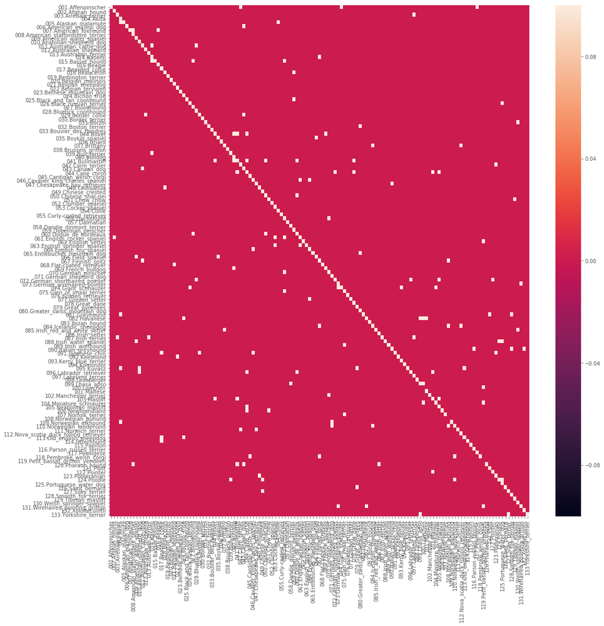

```python
df = pd.DataFrame({'actual':actual,'pred':predicted})
cm = confusion_matrix(df['actual'], df['pred'], labels=classes)
fig, ax = plt.subplots(figsize=(18, 18))
_ = sns.heatmap(cm, ax=ax, yticklabels=classes, xticklabels=classes, robust=True)

df['count'] = 1
```

### Most Confusing Classes:

As we can see, the confusion matrix itself becomes very confusing due to large number of classes here (100+). The next way is to plot the most confusing pairs of classes in decreasing order of confusion. Below plot shows the same

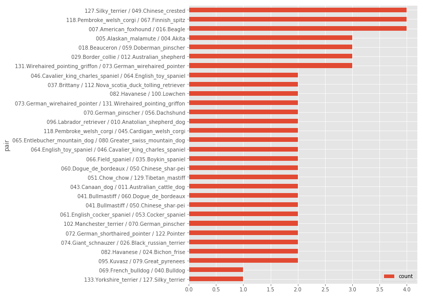

```python
misclass_df = df[df['actual'] != df['pred']].groupby(['actual', 'pred']).sum().sort_values(['count'], ascending=False).reset_index()
misclass_df['pair'] = misclass_df['actual'] + ' / ' + misclass_df['pred']
misclass_df = misclass_df[['pair', 'count']].take(range(30))


misclass_df.sort_values(['count']).plot.barh(figsize=(8, 10), x=misclass_df['pair'])
```

### Some Observations

#### Silky Terrier

[figure not shown]

#### Chinese Crested

[figure not shown]

### (IMPLEMENTATION) Predict Dog Breed with the Model

Write a function that takes an image path as input and returns the dog breed (`Affenpinscher`, `Afghan hound`, etc) that is predicted by your model.

```python
import torch
import os
from torchvision import datasets
from PIL import ImageFile
ImageFile.LOAD_TRUNCATED_IMAGES = True

### TODO: Write data loaders for training, validation, and test sets
## Specify appropriate transforms, and batch_sizes

import torchvision.transforms as transforms
from torch.utils.data.sampler import SubsetRandomSampler

# number of subprocesses to use for data loading
num_workers = 0
# how many samples per batch to load
batch_size = 20
# percentage of training set to use as validation
valid_size = 0.2
#print(os.listdir('/data/dog_images/test'))
# convert data to a normalized torch.FloatTensor
transform = transforms.Compose([
    transforms.RandomAffine(degrees=180),
    transforms.CenterCrop(299),
    transforms.ToTensor()
    ])
transform2 = transforms.Compose([
    transforms.CenterCrop(299),
    transforms.ToTensor()
    ])

# choose the training and test datasets
train_data = datasets.ImageFolder(root='/data/dog_images/train',transform=transform)
valid_data = datasets.ImageFolder(root='/data/dog_images/valid',transform=transform)
test_data = datasets.ImageFolder(root='/data/dog_images/test',transform=transform2)

print(train_data.classes[0])
# prepare data loaders (combine dataset and sampler)
train_loader = torch.utils.data.DataLoader(train_data, batch_size=batch_size,
    shuffle=True, num_workers=num_workers)
print(train_loader)
valid_loader = torch.utils.data.DataLoader(valid_data, batch_size=batch_size,
    shuffle=True, num_workers=num_workers)
test_loader = torch.utils.data.DataLoader(test_data, batch_size=batch_size,
    num_workers=num_workers)

# specify the image classes
classes = os.listdir('/data/dog_images/train')
print(len(classes))
bid = 1
for a,b in train_loader:
    print("batch: "+ str(bid))
    print(a.shape)
    print(b.shape)
    bid+=1
    break
```

```
001.Affenpinscher
<torch.utils.data.dataloader.DataLoader object at 0x7f470d74a588>
133
batch: 1
torch.Size([20, 3, 299, 299])
torch.Size([20])
```

```python
import torch
import torchvision.models as models
import os
from torchvision import datasets
import torch.nn as nn
from tqdm import tqdm
from PIL import Image
#ImageFile.LOAD_TRUNCATED_IMAGES = True
import torchvision.transforms as transforms
from torch.utils.data.sampler import SubsetRandomSampler
import cv2


### Human Detector ####
import numpy as np
import cv2
import matplotlib.pyplot as plt
%matplotlib inline

# extract pre-trained face detector
face_cascade = cv2.CascadeClassifier('haarcascades/haarcascade_frontalface_alt.xml')

# returns "True" if face is detected in image stored at img_path
def face_detector(img_path):
    img = cv2.imread(img_path)
    gray = cv2.cvtColor(img, cv2.COLOR_BGR2GRAY)
    faces = face_cascade.detectMultiScale(gray)
    return len(faces) > 0

### Dog Detector Using VGG16

## Load VGG for Dog Detection ###

# define VGG16 model
VGG16 = models.vgg16(pretrained=True)

# check if CUDA is available
use_cuda = torch.cuda.is_available()
print(use_cuda)

# move model to GPU if CUDA is available
if use_cuda:
    VGG16 = VGG16.cuda()



from PIL import Image
import torchvision.transforms as transforms
import cv2

data_transform = transforms.Compose([transforms.CenterCrop(224),transforms.ToTensor()])

def VGG16_predict(img_path):
    '''
    Use pre-trained VGG-16 model to obtain index corresponding to
    predicted ImageNet class for image at specified path

    Args:
        img_path: path to an image

    Returns:
        Index corresponding to VGG-16 model's prediction
    '''

    ## TODO: Complete the function.
    ## Load and pre-process an image from the given img_path
    ## Return the *index* of the predicted class for that image
    VGG16.eval()
    img = (data_transform(Image.open(img_path)).float()).unsqueeze(0)
    if use_cuda:
        img = img.cuda()
    output = VGG16(img)
    max_val, preds_tensor = torch.max(output, 1)
    #print('Dog Detector: '+str(max_val))
    preds = np.squeeze(preds_tensor.numpy()) if not use_cuda else np.squeeze(preds_tensor.cpu().numpy())
    #print(preds)
    return preds # predicted class index

### returns "True" if a dog is detected in the image stored at img_path
def dog_detector(img_path):
    ## TODO: Complete the function.
    myclassind = VGG16_predict(img_path)

    return (myclassind<269 and myclassind>150) # true/false



## TODO: Specify model architecture
model_transfer = models.inception_v3(pretrained=True)

for param in model_transfer.parameters():
    param.requires_grad = False

num_classes = len(os.listdir('/data/dog_images/train'))
model_transfer.fc = nn.Linear(2048, num_classes, bias = True)

if use_cuda:
    model_transfer = model_transfer.cuda()
    model_transfer.load_state_dict(torch.load('model_transfer.pt'))
    #model_transfer = model_transfer.cpu()
    #torch.save(model_transfer.state_dict(), 'inception_model_transfer_cpu.pt')
else:
    model_transfer.load_state_dict(torch.load('inception_model_transfer_cpu.pt'))


#model_transfer_trained = model_transfer
#model_transfer.load_state_dict(torch.load('model_transfer.pt'))
transform2 = transforms.Compose([
    transforms.CenterCrop(299),
    transforms.ToTensor()
    ])


def breed_predict(img_path):
    ## TODO: Complete the function.
    ## Load and pre-process an image from the given img_path
    ## Return the *index* of the predicted class for that image
    #model_transfer_trained
    with torch.no_grad():
        model_transfer.eval()
        img = (transform2(Image.open(img_path)).float()).unsqueeze(0)
        if use_cuda:
            img = img.cuda()

        output = model_transfer(img)
        pred = output.data.max(1, keepdim=True)[1]


    return pred[0] # predicted class index
```

```
Downloading: "https://download.pytorch.org/models/vgg16-397923af.pth" to /root/.torch/models/vgg16-397923af.pth
```

```
False
```

```
Downloading: "https://download.pytorch.org/models/inception_v3_google-1a9a5a14.pth" to /root/.torch/models/inception_v3_google-1a9a5a14.pth
```

```python
### TODO: Write a function that takes a path to an image as input
### and returns the dog breed that is predicted by the model.

# list of class names by index, i.e. a name can be accessed like class_names[0]
class_names = [item[4:].replace("_", " ") for item in train_data.classes]

classes = train_data.classes

def predict_breed_transfer(img_path, example = False):
    # load the image and return the predicted breed
    class_index = breed_predict(img_path)
    if not example:
        return class_names[class_index]
    else:
        images = os.listdir('/data/dog_images/train/'+classes[class_index])
        example_path = '/data/dog_images/train/'+classes[class_index]+'/'+images[0]
        return class_names[class_index], example_path
```

## Step 5: Write your Algorithm

Write an algorithm that accepts a file path to an image and first determines whether the image contains a human, dog, or neither. Then,

- if a **dog** is detected in the image, return the predicted breed.
- if a **human** is detected in the image, return the resembling dog breed.
- if **neither** is detected in the image, provide output that indicates an error.

You are welcome to write your own functions for detecting humans and dogs in images, but feel free to use the `face_detector` and `human_detector` functions developed above. You are **required** to use your CNN from Step 4 to predict dog breed.

Some sample output for our algorithm is provided below, but feel free to design your own user experience!

[figure not shown]

### (IMPLEMENTATION) Write your Algorithm

```python
import shutil
import os
shutil.rmtree('ExternalImages')

shutil.rmtree('ExternalImages2')

shutil.rmtree('ExternalImages3')

shutil.rmtree('ExternalImages4')
os.listdir('.')
```

```
['dog_app.ipynb',
 'all_train_transfer.pkl',
 'dogImages',
 'all_valid_transfer.pkl',
 'model_scratch.pt',
 'all_targets.pkl',
 'all_pred.pkl',
 'haarcascades',
 'README.md',
 'inception_model_transfer_cpu.pt',
 'model_transfer.pt',
 'test_loss.pkl',
 '.ipynb_checkpoints',
 'dogImages.zip',
 'images']
```

### Download Images From Internet for Testing:

Let's download some images from internet for testing our algorithm. We have good mix humans, almost humans (!!), dogs, cartoon dogs, cat, etc.

```python
## Download few images
import os
import shutil
from PIL import Image
import PIL.ImageOps
foldername = 'ExternalImages'
try:
    shutil.rmtree(foldername)

except Exception as e:
    print(str(e))

os.mkdir(foldername)
import requests

def downloadImage(image_url,filename,invert_it = False):
    img_data = requests.get(image_url).content
    print(filename)
    print(image_url.split('.')[-1])
    filename = foldername+'/'+filename+'.'+image_url.split('.')[-1]
    print(filename)
    with open(filename, 'wb') as handler:
        handler.write(img_data)
    if not invert_it:
        return
    image = Image.open(filename)
    inverted_image = PIL.ImageOps.invert(image)
    inverted_image.save(filename)



inames = ['Laurel and Hardy','The Mask', 'Pluto', 'German Shephard','Cat', 'Dog','Avatar','WallE']

s = ['https://static.independent.co.uk/s3fs-public/thumbnails/image/2018/10/12/11/laurel-and-hardy.jpg', 'https://i.ebayimg.com/images/g/pqUAAOSwzaJX3QUy/s-l300.jpg', 'https://previews.123rf.com/images/chutimakuanamon/chutimakuanamon1709/chutimakuanamon170900063/86773647-pluto-dog-walking-illustration-cartoon.jpg', 'http://www.dogbreedslist.info/uploads/allimg/dog-pictures/German-Shepherd-Dog-2.jpg', 'http://www.catbreedslist.com/uploads/allimg/cat-pictures/Norwegian-Forest-Cat-1.jpg', 'https://cdn.cliqueinc.com/cache/posts/253247/biggest-dogs-in-the-world-253247-1522188066764-main.700x0c.jpg','https://1.bp.blogspot.com/-MUZ-dMQAcPk/VHr-18XY0BI/AAAAAAAAB4Q/7lQgCRcRfVc/s1600/digital%2Bpainting%2Bof%2Bavtar.jpg','https://images-na.ssl-images-amazon.com/images/I/51s0Nl7DVSL._SL500_AC_SS350_.jpg']

#inames = ['Mr Bean','The Mask', 'Pluto', 'German Shephard','Cat', 'Smallest Dog']
#s = ['http://waterfordwhispersnews.com/wp-content/uploads/2018/07/feature-12-1.jpg', 'https://i.ebayimg.com/images/g/pqUAAOSwzaJX3QUy/s-l300.jpg', 'https://previews.123rf.com/images/chutimakuanamon/chutimakuanamon1709/chutimakuanamon170900063/86773647-pluto-dog-walking-illustration-cartoon.jpg', 'http://www.dogbreedslist.info/uploads/allimg/dog-pictures/German-Shepherd-Dog-2.jpg', 'http://r.ddmcdn.com/s_f/o_1/cx_462/cy_245/cw_1349/ch_1349/w_720/APL/uploads/2015/06/caturday-shutterstock_149320799.jpg', 'https://i.ytimg.com/vi/V06b-FCdIhA/maxresdefault.jpg']
#flags = ['True','False','True','False','True','True']
flags = [False,False,False,False,False,False,False,False]
t = 0
for i in s:
    downloadImage(i,inames[t],invert_it=flags[t])
    t+=1
#downloadImage(s2,invert_it=False)
print(os.listdir(foldername))
```

```
Laurel and Hardy
jpg
ExternalImages/Laurel and Hardy.jpg
The Mask
jpg
ExternalImages/The Mask.jpg
Pluto
jpg
ExternalImages/Pluto.jpg
German Shephard
jpg
ExternalImages/German Shephard.jpg
Cat
jpg
ExternalImages/Cat.jpg
Dog
jpg
ExternalImages/Dog.jpg
Avatar
jpg
ExternalImages/Avatar.jpg
WallE
jpg
ExternalImages/WallE.jpg
['The Mask.jpg', 'Pluto.jpg', 'WallE.jpg', 'Cat.jpg', 'Dog.jpg', 'Avatar.jpg', 'Laurel and Hardy.jpg', 'German Shephard.jpg']
```

## Step 6: Test Your Algorithm

In this section, you will take your new algorithm for a spin! What kind of dog does the algorithm think that *you* look like? If you have a dog, does it predict your dog's breed accurately? If you have a cat, does it mistakenly think that your cat is a dog?

### (IMPLEMENTATION) Test Your Algorithm on Sample Images!

Test your algorithm at least six images on your computer. Feel free to use any images you like. Use at least two human and two dog images.

**Question 6:** Is the output better than you expected :) ? Or worse :( ? Provide at least three possible points of improvement for your algorithm.

**Answer:** (Three possible points for improvement)

I tried few interesting images via our algorithm to check if human or dog and corresponding breed.

I am showing the image followed by the detected breed and example image from that breed.

Analysis follows the code cell.

```
########################################################################
The Mask.jpg
Hello Human, You look like a Dogue de bordeaux
```

[figure not shown]

```
Dogue de bordeaux
```

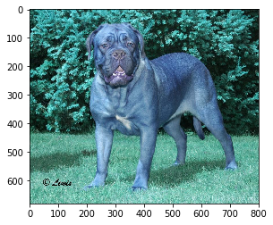

```
########################################################################
Pluto.jpg
Hello Human, You look like a Bullmastiff
```

[figure not shown]

```
Bullmastiff
```

[figure not shown]

```
########################################################################
WallE.jpg
```

[figure not shown]

```
Oh My God...!!! I see an Alien, Call 911...!!!

########################################################################
Cat.jpg
Hello Human, You look like a American eskimo dog
```

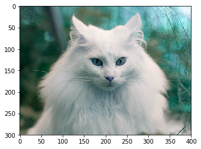

```
American eskimo dog
```

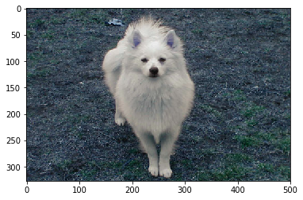

```
########################################################################
Dog.jpg
Hello Doggy, I think you must be Great dane
```

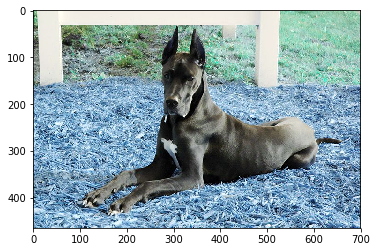

```
Great dane
```

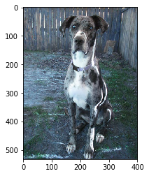

```
########################################################################
Avatar.jpg
Hello Human, You look like a Poodle
```

[figure not shown]

```
Poodle
```

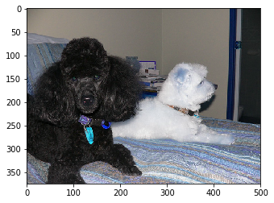

```
########################################################################
Laurel and Hardy.jpg
Hello Doggy, I think you must be Irish water spaniel
```

[figure not shown]

```
Irish water spaniel
```

[3 more figures not shown]

```python
### TODO: Write your algorithm.
### Feel free to use as many code cells as needed.
import matplotlib.pyplot as plt
import matplotlib
%matplotlib inline

import cv2
myImages = os.listdir(foldername)
def run_app(img_path,imgname=None):

    print('')
    print('########################################################################')

    display_msg = ''
    img = cv2.imread(img_path)
    #plt.imshow(img)
    #plt.show()
    # convert BGR image to grayscale
    isDog = dog_detector(img_path)
    if isDog:
        display_msg = "Hello Doggy, I think you must be "

    else:
        isHuman = face_detector(img_path)
        if isHuman:
            display_msg = "Hello Human, You look like a "
        else:
            print(imgname)
            plt.imshow(img)
            plt.show()
            print("Oh My God...!!! I see an Alien, Call 911...!!!")
            return


    breed, example_path = predict_breed_transfer(img_path,example=True)
    display_msg = display_msg + breed
    print(imgname)
    print(display_msg)
    #print(example_path)
    plt.imshow(img)
    plt.show()
    print(breed)
    example_img = cv2.imread(example_path)
    plt.imshow(example_img)
    #axarr[1].imshow(example_img)
    #axarr[1,0].imshow(image_datas[2])
    #axarr[1,1].imshow(image_datas[3])
    plt.show()
    return

for img in myImages:
    run_app(foldername+'/'+img,img)
```

### Obeservations:

The results are no doubt funny...!!!

In general, I would say that, human detector using face detection is not a very good idea. Wherever it sees some eyes, nose and all, it thinks there is a human.

### Improvements:

Following are improvements that can be made:

```python
## TODO: Execute your algorithm from Step 6 on
## at least 6 images on your computer.
## Feel free to use as many code cells as needed.

## suggested code, below
for file in np.hstack((human_files[:3], dog_files[:3])):
    run_app(file)
```

[output not shown]